# MLDS: Introduction to R

Wendy Geronimo & Jasmine Xu

2024-04-09

[figure not shown]

# Section 1: An introductory guide to R

Welcome! Today, we will explore the basics of R programming and dive into data visualization using ggplot2, one of the most popular packages for creating graphics in R.

### Brief Overview of R:

- R is widely used for data analysis and visualization in various fields, including academia, industry, and research.
- Its applications range from simple data manipulation to complex statistical modeling and machine learning.

### Installing R and RStudio:

1. R can be installed from the Comprehensive R Archive Network (CRAN) website. https://cran.r-project.org/
2. Once R is installed, you can download RStudio from the Posit website. RStudio is an integrated development environment (IDE) for R that provides a user-friendly interface for coding and visualization. (https://www.rstudio.com/products/rstudio/download/)

### When you open RStudio, you will see 4 panels:

[figure not shown]

# Section 2: R Markdown Overview & Basic Syntax

### Some ways to run code:

```
• have cursor anywhere on the line
• highlight what you want to run
```

### Some Shortcuts Windows/Mac (replace ctrl with cmd)

```
• ctrl + enter; run selected line(s)
• ctrl + shift + enter; run current code chunk
• ctrl + alt + N; run next code chunk
• ctrl + l; clear console
• esc; to escape the current line in the console
```

### Help

```
• help()
• ?____
 try on console: help(base)
                 ?base
```

### Basic Syntax

[figure not shown]

The **assignment operator** in R is **<-**, the less than sign and hyphen without a space in-between, creates a variable in the environment.

```r
# assignment operator (<-)
# saving 7 as an object obj
obj <- 7
print(obj)
```

```
## [1] 7
```

```r
# can use single or double quotes ("/')
single <- 'Hello World!'
double <- "Hello World!"

# overall, the output is in double quotes
print(single)
```

```
## [1] "Hello World!"
```

```r
print(double)
```

```
## [1] "Hello World!"
```

```r
# not on environment because there's nothing assigned to them
print(7)
```

```
## [1] 7
```

```r
print('Hello World')
```

```
## [1] "Hello World"
```

### Operators

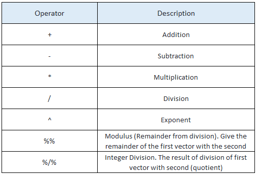

#### examples:

```
• 5 * 7 + 9   # 44
• 7 + 9 * 5   # 52, does multiplication first
• 5 * (7 + 9) # 80, best to use parenthesis!
```

#### **additional calculations**:

```
• mean()  # mean
• var()   # variance
• sd()    # standard deviation
• prod()  # product
• log()   # logarithms
• sqrt()  # square root
• x^     # exponential
```

### Data Types

In R, we encounter various data types that include the following:

• **Character**: Used for text data, enclosed within “quotation marks”. ex. “Hello”, “40 Acres”

• **Numeric**: Represents numbers, integers and floats. ex. 12, 3.14, -7 *(If you say numeric data is a character, you won’t be able to do any math with it.)*

• **Logical**: Consists of boolean values TRUE and FALSE. ex. TRUE, FALSE

• **Vectors**: A sequence of elements of the same data type.

*c() concatenation- input data you want to put together inside brackets, each separated by a comma*

- **Numeric vector**: c(1, 2, 3, 4, 5)
- **Character vector**: c(“apple”, “banana”, “orange”)
- **Logical vector** (Booleans): c(TRUE, FALSE, TRUE)

```r
# examples of creating and manipulating vectors
v1 <- 5:15 # : stands for to in a series of numbers
v2 <- c(4,6,8,10,8,6,1)

# accessing elements in vectors
v1[4]
```

```
## [1] 8
```

```r
v2[2:5]
```

```
## [1]  6  8 10  8
```

```r
# use ifelse for vectorized if/else operations
y <- c(1, 5, 10, 15, 20)
result <- ifelse(y > 10, "Greater than 10", "Less than or equal to 10")
print(result)
```

```
## [1] "Less than or equal to 10" "Less than or equal to 10"
## [3] "Less than or equal to 10" "Greater than 10"
## [5] "Greater than 10"
```

## Important note!

Just because something is a *number* doesn’t mean R thinks it’s numeric!

```r
a <- 15
b <- "6"

# a * b
# There would be an error: "non-numeric argument to binary operator"
# because b is set as a string

# Convert character to numeric using as.numeric() function
a * as.numeric(b) # now it works! :)
```

```
## [1] 90
```

```r
# check stucture: b changes from "chr" to "num"
str(b)
```

```
##  chr "6"
```

```r
str(as.numeric(b))
```

```
##  num 6
```

```r
# to fix b to be a number permanently
b <- as.numeric(b)
b
```

```
## [1] 6
```

## Variable Names

Choosing descriptive and consistent variable names is crucial for writing clear and maintainable code. Here are some guidelines:

1. **Descriptive Names**: Clearly describe the variable’s purpose or content
2. **Avoid Abbreviations**: Minimize abbreviation to maintain clarity
3. **Consistent Convention**: Stick to naming conventions like camelCase
4. **Start with a Letter**: Variable names must start with a letter
5. **Avoid Reserved Keywords**: Don’t use reserved keywords as variable names

Examples: • **camelCase**: `myVariableName` • **snake_case**: `my_variable_name` • **PascalCase**: `MyVariableName`

These examples demonstrate clear and meaningful variable names, enhancing readability and collaboration!

**DO NOT CREATE VARIABLE NAMES THAT FALL INTO THE RESERVED WORDS LIKE THOSE SHOWN BELOW!** Those are built-in functions, meaning they’re used for specific purposes within the language’s syntax and functionality.

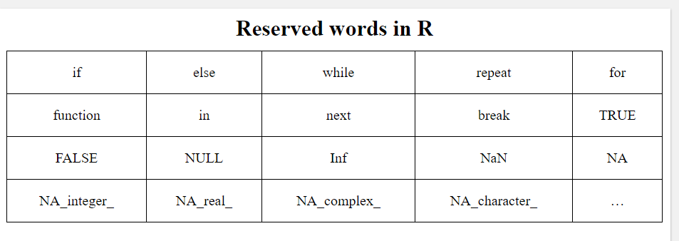

# Section 3. Loading Data and Exploring Dataset

### Loading Packages/Libraries

The library tidyverse is a collection of packages that allows us to manipulate and visualize data.

```r
library(tidyverse)
```

### Dataset

The `iris’ dataset is a classic dataset in machine learning and data science. The dataset consists of 150 samples of iris flowers, each belonging to one of three species: setosa, versicolor, or virginica. It includes 4 features sepal length/width and petal length/width, all measured in centimeters.

Look up the documentation for this data frame with a description of the variables by typing `?iris` **in the console** pane.

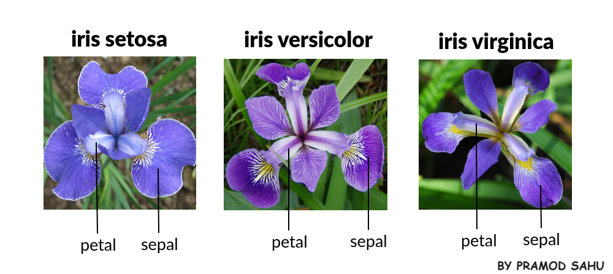

```r
# note: for datasets that are not already in R use read_csv (comma separated value)
# df <- read_csv("dataset_path/name_of_dataset.csv")

# load the iris dataset, already in R!
data(iris)

View(iris) # view dataset
head(iris) # see top 6 rows, can edit by head(iris, 5), top 5 rows
```

```
##   Sepal.Length Sepal.Width Petal.Length Petal.Width Species
## 1          5.1         3.5          1.4         0.2  setosa
## 2          4.9         3.0          1.4         0.2  setosa
## 3          4.7         3.2          1.3         0.2  setosa
## 4          4.6         3.1          1.5         0.2  setosa
## 5          5.0         3.6          1.4         0.2  setosa
## 6          5.4         3.9          1.7         0.4  setosa
```

```r
tail(iris) # see bottom 6 rows, can also be edited!
```

```
##     Sepal.Length Sepal.Width Petal.Length Petal.Width   Species
## 145          6.7         3.3          5.7         2.5 virginica
## 146          6.7         3.0          5.2         2.3 virginica
## 147          6.3         2.5          5.0         1.9 virginica
## 148          6.5         3.0          5.2         2.0 virginica
## 149          6.2         3.4          5.4         2.3 virginica
## 150          5.9         3.0          5.1         1.8 virginica
```

```r
nrow(iris) # total rows in dataset
```

```
## [1] 150
```

```r
ncol(iris) # total columns in dataset
```

```
## [1] 5
```

```r
colnames(iris) # column names
```

```
## [1] "Sepal.Length" "Sepal.Width"  "Petal.Length" "Petal.Width"  "Species"
```

### Data Wrangling

Data wrangling is the process of cleaning, transforming, and organizing raw data to make it usable for analysis and visualization!

Loading the dplyr library will allow us to do that.

```r
# Uncomment if you do not have dplyr installed
# install.packages("dplyr")
library(dplyr)
```

#### Core Functions

1. filter() choose rows/observations
2. arrange() sort rows/observations
3. select() choose columns/variables
4. mutate() create new columns/variables
5. summarize() calculate summaries
6. group_by() designate groups of data

#### What is a pipe?

The pipe **%>%** lets you easily connect functions together, so you can perform a series of actions on your data step by step, making your code cleaner and easier to follow.

### Filter

Use `filter()` to choose rows/observations verifying some conditions. Use conditional statements such as `<`, `>`, `>=`, `<=`, `==`, `is.na()`, `&`, `|`, `!`, `%in%`, …

```r
# Filter a categorical variable
iris %>%
  filter(Species == "setosa")
```

```
##    Sepal.Length Sepal.Width Petal.Length Petal.Width Species
## 1           5.1         3.5          1.4         0.2  setosa
## 2           4.9         3.0          1.4         0.2  setosa
## 3           4.7         3.2          1.3         0.2  setosa
## 4           4.6         3.1          1.5         0.2  setosa
## 5           5.0         3.6          1.4         0.2  setosa
## 6           5.4         3.9          1.7         0.4  setosa
## 7           4.6         3.4          1.4         0.3  setosa
## 8           5.0         3.4          1.5         0.2  setosa
## 9           4.4         2.9          1.4         0.2  setosa
## 10          4.9         3.1          1.5         0.1  setosa
## 11          5.4         3.7          1.5         0.2  setosa
## 12          4.8         3.4          1.6         0.2  setosa
## 13          4.8         3.0          1.4         0.1  setosa
## 14          4.3         3.0          1.1         0.1  setosa
```

[output cut: 36 more lines]

```r
# Filter with multiple criteria
iris %>%
  filter(Species == "versicolor" & Petal.Width > 1)
```

```
##    Sepal.Length Sepal.Width Petal.Length Petal.Width    Species
## 1           7.0         3.2          4.7         1.4 versicolor
## 2           6.4         3.2          4.5         1.5 versicolor
## 3           6.9         3.1          4.9         1.5 versicolor
## 4           5.5         2.3          4.0         1.3 versicolor
## 5           6.5         2.8          4.6         1.5 versicolor
## 6           5.7         2.8          4.5         1.3 versicolor
## 7           6.3         3.3          4.7         1.6 versicolor
## 8           6.6         2.9          4.6         1.3 versicolor
## 9           5.2         2.7          3.9         1.4 versicolor
## 10          5.9         3.0          4.2         1.5 versicolor
## 11          6.1         2.9          4.7         1.4 versicolor
## 12          5.6         2.9          3.6         1.3 versicolor
## 13          6.7         3.1          4.4         1.4 versicolor
## 14          5.6         3.0          4.5         1.5 versicolor
```

[output cut: 29 more lines]

```r
# Filter a numeric variable to a given range
iris %>%
  filter(between(Sepal.Length, 5.5, 6.5)) # between(variable, min, max)
```

```
##    Sepal.Length Sepal.Width Petal.Length Petal.Width    Species
## 1           5.8         4.0          1.2         0.2     setosa
## 2           5.7         4.4          1.5         0.4     setosa
## 3           5.7         3.8          1.7         0.3     setosa
## 4           5.5         4.2          1.4         0.2     setosa
## 5           5.5         3.5          1.3         0.2     setosa
## 6           6.4         3.2          4.5         1.5 versicolor
## 7           5.5         2.3          4.0         1.3 versicolor
## 8           6.5         2.8          4.6         1.5 versicolor
## 9           5.7         2.8          4.5         1.3 versicolor
## 10          6.3         3.3          4.7         1.6 versicolor
## 11          5.9         3.0          4.2         1.5 versicolor
## 12          6.0         2.2          4.0         1.0 versicolor
## 13          6.1         2.9          4.7         1.4 versicolor
## 14          5.6         2.9          3.6         1.3 versicolor
```

[output cut: 54 more lines]

```r
# Filter rows by indexes using slice()
iris %>%
  slice(1:10)
```

```
##    Sepal.Length Sepal.Width Petal.Length Petal.Width Species
## 1           5.1         3.5          1.4         0.2  setosa
## 2           4.9         3.0          1.4         0.2  setosa
## 3           4.7         3.2          1.3         0.2  setosa
## 4           4.6         3.1          1.5         0.2  setosa
## 5           5.0         3.6          1.4         0.2  setosa
## 6           5.4         3.9          1.7         0.4  setosa
## 7           4.6         3.4          1.4         0.3  setosa
## 8           5.0         3.4          1.5         0.2  setosa
## 9           4.4         2.9          1.4         0.2  setosa
## 10          4.9         3.1          1.5         0.1  setosa
```

```r
# Filter rows which contain a certain pattern/string
iris %>%
  filter(grepl("setosa", Species))
```

```
##    Sepal.Length Sepal.Width Petal.Length Petal.Width Species
## 1           5.1         3.5          1.4         0.2  setosa
## 2           4.9         3.0          1.4         0.2  setosa
## 3           4.7         3.2          1.3         0.2  setosa
## 4           4.6         3.1          1.5         0.2  setosa
## 5           5.0         3.6          1.4         0.2  setosa
## 6           5.4         3.9          1.7         0.4  setosa
## 7           4.6         3.4          1.4         0.3  setosa
## 8           5.0         3.4          1.5         0.2  setosa
## 9           4.4         2.9          1.4         0.2  setosa
## 10          4.9         3.1          1.5         0.1  setosa
## 11          5.4         3.7          1.5         0.2  setosa
## 12          4.8         3.4          1.6         0.2  setosa
## 13          4.8         3.0          1.4         0.1  setosa
## 14          4.3         3.0          1.1         0.1  setosa
```

[output cut: 36 more lines]

### Arrange

Use `arrange()` to sort rows/observations on some conditions. Default is ascending (from least to greatest or alphabetically for categories) but to sort in the other direction use `desc()`.

```r
# Sort by Sepal.Width, least-to-greatest
iris %>%
  arrange(Sepal.Width)
```

```
##     Sepal.Length Sepal.Width Petal.Length Petal.Width    Species
## 1            5.0         2.0          3.5         1.0 versicolor
## 2            6.0         2.2          4.0         1.0 versicolor
## 3            6.2         2.2          4.5         1.5 versicolor
## 4            6.0         2.2          5.0         1.5  virginica
## 5            4.5         2.3          1.3         0.3     setosa
## 6            5.5         2.3          4.0         1.3 versicolor
## 7            6.3         2.3          4.4         1.3 versicolor
## 8            5.0         2.3          3.3         1.0 versicolor
## 9            4.9         2.4          3.3         1.0 versicolor
## 10           5.5         2.4          3.8         1.1 versicolor
## 11           5.5         2.4          3.7         1.0 versicolor
## 12           5.6         2.5          3.9         1.1 versicolor
## 13           6.3         2.5          4.9         1.5 versicolor
## 14           5.5         2.5          4.0         1.3 versicolor
```

[output cut: 136 more lines]

```r
# Sort by Species alphabetically, Sepal.Length and Petal.Length chronologically
iris %>%
  arrange(Species, Sepal.Length, Petal.Length)
```

```
##     Sepal.Length Sepal.Width Petal.Length Petal.Width    Species
## 1            4.3         3.0          1.1         0.1     setosa
## 2            4.4         3.0          1.3         0.2     setosa
## 3            4.4         3.2          1.3         0.2     setosa
## 4            4.4         2.9          1.4         0.2     setosa
## 5            4.5         2.3          1.3         0.3     setosa
## 6            4.6         3.6          1.0         0.2     setosa
## 7            4.6         3.4          1.4         0.3     setosa
## 8            4.6         3.2          1.4         0.2     setosa
## 9            4.6         3.1          1.5         0.2     setosa
## 10           4.7         3.2          1.3         0.2     setosa
## 11           4.7         3.2          1.6         0.2     setosa
## 12           4.8         3.0          1.4         0.1     setosa
## 13           4.8         3.0          1.4         0.3     setosa
## 14           4.8         3.4          1.6         0.2     setosa
```

[output cut: 136 more lines]

### Select

```r
# Select to keep only some variables
iris %>%
  select(Species, Sepal.Length, Petal.Length)
```

```
##        Species Sepal.Length Petal.Length
## 1       setosa          5.1          1.4
## 2       setosa          4.9          1.4
## 3       setosa          4.7          1.3
## 4       setosa          4.6          1.5
## 5       setosa          5.0          1.4
## 6       setosa          5.4          1.7
## 7       setosa          4.6          1.4
## 8       setosa          5.0          1.5
## 9       setosa          4.4          1.4
## 10      setosa          4.9          1.5
## 11      setosa          5.4          1.5
## 12      setosa          4.8          1.6
## 13      setosa          4.8          1.4
## 14      setosa          4.3          1.1
```

[output cut: 136 more lines]

```r
# Select to keep columns using indexes
iris %>%
  select(1, 3, 5)
```

```
##     Sepal.Length Petal.Length    Species
## 1            5.1          1.4     setosa
## 2            4.9          1.4     setosa
## 3            4.7          1.3     setosa
## 4            4.6          1.5     setosa
## 5            5.0          1.4     setosa
## 6            5.4          1.7     setosa
## 7            4.6          1.4     setosa
## 8            5.0          1.5     setosa
## 9            4.4          1.4     setosa
## 10           4.9          1.5     setosa
## 11           5.4          1.5     setosa
## 12           4.8          1.6     setosa
## 13           4.8          1.4     setosa
## 14           4.3          1.1     setosa
```

[output cut: 136 more lines]

```r
# Drop variables using "-"
iris %>%
  select(-Species, -Sepal.Width)
```

```
##     Sepal.Length Petal.Length Petal.Width
## 1            5.1          1.4         0.2
## 2            4.9          1.4         0.2
## 3            4.7          1.3         0.2
## 4            4.6          1.5         0.2
## 5            5.0          1.4         0.2
## 6            5.4          1.7         0.4
## 7            4.6          1.4         0.3
## 8            5.0          1.5         0.2
## 9            4.4          1.4         0.2
## 10           4.9          1.5         0.1
## 11           5.4          1.5         0.2
## 12           4.8          1.6         0.2
## 13           4.8          1.4         0.1
## 14           4.3          1.1         0.1
```

[output cut: 136 more lines]

```r
# Move Petal.Width to the front
# Use everything() to keep everything else in the same order
iris %>%
  select(Petal.Width, everything())
```

```
##     Petal.Width Sepal.Length Sepal.Width Petal.Length    Species
## 1           0.2          5.1         3.5          1.4     setosa
## 2           0.2          4.9         3.0          1.4     setosa
## 3           0.2          4.7         3.2          1.3     setosa
## 4           0.2          4.6         3.1          1.5     setosa
## 5           0.2          5.0         3.6          1.4     setosa
## 6           0.4          5.4         3.9          1.7     setosa
## 7           0.3          4.6         3.4          1.4     setosa
## 8           0.2          5.0         3.4          1.5     setosa
## 9           0.2          4.4         2.9          1.4     setosa
## 10          0.1          4.9         3.1          1.5     setosa
## 11          0.2          5.4         3.7          1.5     setosa
## 12          0.2          4.8         3.4          1.6     setosa
## 13          0.1          4.8         3.0          1.4     setosa
## 14          0.1          4.3         3.0          1.1     setosa
```

[output cut: 136 more lines]

```r
# Select variables/columns by partial name
iris %>%
  select(starts_with("Sepal"))
```

```
##     Sepal.Length Sepal.Width
## 1            5.1         3.5
## 2            4.9         3.0
## 3            4.7         3.2
## 4            4.6         3.1
## 5            5.0         3.6
## 6            5.4         3.9
## 7            4.6         3.4
## 8            5.0         3.4
## 9            4.4         2.9
## 10           4.9         3.1
## 11           5.4         3.7
## 12           4.8         3.4
## 13           4.8         3.0
## 14           4.3         3.0
```

[output cut: 136 more lines]

```r
# Select and rename...
iris %>%
  select(FlowerType = Species,
         "Sepal_Width" = Sepal.Width,
         "Petal_Width" = Petal.Width)
```

```
##     FlowerType Sepal_Width Petal_Width
## 1       setosa         3.5         0.2
## 2       setosa         3.0         0.2
## 3       setosa         3.2         0.2
## 4       setosa         3.1         0.2
## 5       setosa         3.6         0.2
## 6       setosa         3.9         0.4
## 7       setosa         3.4         0.3
## 8       setosa         3.4         0.2
## 9       setosa         2.9         0.2
## 10      setosa         3.1         0.1
## 11      setosa         3.7         0.2
## 12      setosa         3.4         0.2
## 13      setosa         3.0         0.1
## 14      setosa         3.0         0.1
```

[output cut: 136 more lines]

```r
# or just use rename()
iris %>%
  rename(FlowerType = Species,
         "Sepal Width" = Sepal.Width,
         "Petal Width" = Petal.Width)
```

```
##     Sepal.Length Sepal Width Petal.Length Petal Width FlowerType
## 1            5.1         3.5          1.4         0.2     setosa
## 2            4.9         3.0          1.4         0.2     setosa
## 3            4.7         3.2          1.3         0.2     setosa
## 4            4.6         3.1          1.5         0.2     setosa
## 5            5.0         3.6          1.4         0.2     setosa
## 6            5.4         3.9          1.7         0.4     setosa
## 7            4.6         3.4          1.4         0.3     setosa
## 8            5.0         3.4          1.5         0.2     setosa
## 9            4.4         2.9          1.4         0.2     setosa
## 10           4.9         3.1          1.5         0.1     setosa
## 11           5.4         3.7          1.5         0.2     setosa
## 12           4.8         3.4          1.6         0.2     setosa
## 13           4.8         3.0          1.4         0.1     setosa
## 14           4.3         3.0          1.1         0.1     setosa
```

[output cut: 136 more lines]

```r
# Compare select() and pull()
petal_lengths_df <- iris %>% select(Petal.Length)
petal_lengths_vec <- iris %>% pull(Petal.Length)
class(petal_lengths_df)
```

```
## [1] "data.frame"
```

```r
class(petal_lengths_vec)
```

```
## [1] "numeric"
```

### Mutate

Use `mutate()` to create new columns/variables:

```r
# Find the ratio of Sepal.Length to Sepal.Width
iris %>%
  mutate(Sepal_Ratio = Sepal.Length / Sepal.Width)
```

```
##     Sepal.Length Sepal.Width Petal.Length Petal.Width    Species Sepal_Ratio
## 1            5.1         3.5          1.4         0.2     setosa    1.457143
## 2            4.9         3.0          1.4         0.2     setosa    1.633333
## 3            4.7         3.2          1.3         0.2     setosa    1.468750
## 4            4.6         3.1          1.5         0.2     setosa    1.483871
## 5            5.0         3.6          1.4         0.2     setosa    1.388889
## 6            5.4         3.9          1.7         0.4     setosa    1.384615
## 7            4.6         3.4          1.4         0.3     setosa    1.352941
## 8            5.0         3.4          1.5         0.2     setosa    1.470588
## 9            4.4         2.9          1.4         0.2     setosa    1.517241
## 10           4.9         3.1          1.5         0.1     setosa    1.580645
## 11           5.4         3.7          1.5         0.2     setosa    1.459459
## 12           4.8         3.4          1.6         0.2     setosa    1.411765
## 13           4.8         3.0          1.4         0.1     setosa    1.600000
## 14           4.3         3.0          1.1         0.1     setosa    1.433333
```

[output cut: 136 more lines]

```r
# Find the square of Petal.Length
iris %>%
  mutate(Petal_Length_Square = Petal.Length^2)
```

```
##     Sepal.Length Sepal.Width Petal.Length Petal.Width    Species
## 1            5.1         3.5          1.4         0.2     setosa
## 2            4.9         3.0          1.4         0.2     setosa
## 3            4.7         3.2          1.3         0.2     setosa
## 4            4.6         3.1          1.5         0.2     setosa
## 5            5.0         3.6          1.4         0.2     setosa
## 6            5.4         3.9          1.7         0.4     setosa
## 7            4.6         3.4          1.4         0.3     setosa
## 8            5.0         3.4          1.5         0.2     setosa
## 9            4.4         2.9          1.4         0.2     setosa
## 10           4.9         3.1          1.5         0.1     setosa
## 11           5.4         3.7          1.5         0.2     setosa
## 12           4.8         3.4          1.6         0.2     setosa
## 13           4.8         3.0          1.4         0.1     setosa
## 14           4.3         3.0          1.1         0.1     setosa
```

[output cut: 287 more lines]

### Summarize

Use `summarize()` to calculate summary statistics on columns/variables. Some useful summary functions: `mean()`, `sd()`, `median()`, `IQR()`, `min()`, `max()`, `n()`, `n_distinct()`, `first()`, `last()`, `nth()`, …

```r
# Find the mean volume
iris %>%
  summarize(mean_width = mean(Sepal.Width))
```

```
##   mean_width
## 1   3.057333
```

```r
# Add more summaries:
# the mean Sepal.Width, number of rows, and number of distinct Species
iris %>%
  summarize(mean_width = mean(Sepal.Width),
            n_rows = n(),
            n_species = n_distinct(Species))
```

```
##   mean_width n_rows n_species
## 1   3.057333    150         3
```

### Group by

This is one very important function! It enables us to create subsets and apply a function to all these subsets. For example, find summaries per Species:

```r
# Find summaries by Species
iris %>%
  group_by(Species) %>% # subsets per Species
  summarize(mean_width = mean(Sepal.Width),
            sd_width = sd(Sepal.Width),
            n = n())
```

```
## # A tibble: 3 x 4
##   Species    mean_width sd_width     n
##   <fct>           <dbl>    <dbl> <int>
## 1 setosa           3.43    0.379    50
## 2 versicolor       2.77    0.314    50
## 3 virginica        2.97    0.322    50
```

```r
# Stop grouping with ungroup()
iris %>%
  group_by(Species) %>% # subsets per Species
  summarize(mean_width = mean(Sepal.Width),
            n = n()) %>% # count how many observations per subgroup
  ungroup() %>% # ungroup to consider all Species
  summarize(n_distinct(n))
```

```
## # A tibble: 1 x 1
##   `n_distinct(n)`
##             <int>
## 1               1
```

# Section 4. Data Visualization with ggplot2

### What is ggplot2?

ggplot2, where “gg” stands for grammar of graphics, is a data visualization package in R. It provides a flexible and intuitive framework for creating graphics.

Some of many advantages of ggplot2:

• Automatic legends, colors, etc.: defaults look good

• Combine multiple variables/datasets on a single graph: easy overlay and facet multiple variables or datasets

• Lots of development/extension packages

We’ll cover:

• Building plots using layers

• Customizing aesthetics and themes

• Creating various types of plots: histograms, scatter plots, and grouped plots

### Visualizing Data

Let’s create some visualizations using ggplot2 with the iris dataset!

### Plotting in base R

Fast and convenient, but not as presentable.

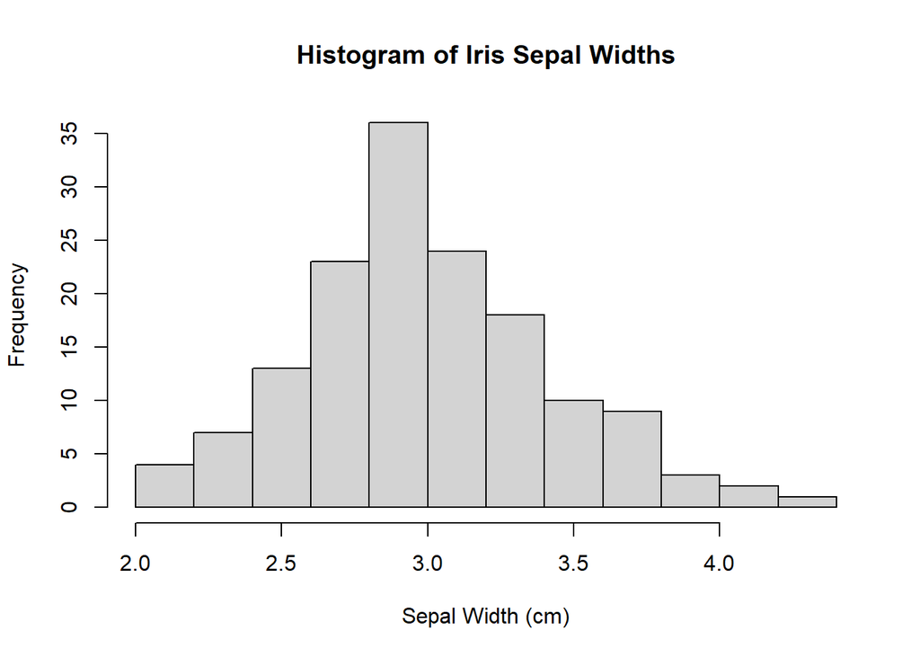

```r
# An example of histograms generated using base R
hist(iris$Sepal.Width,
     main = "Histogram of Iris Sepal Widths",
     xlab = "Sepal Width (cm)",
     breaks = 13)
```

### installing ggplot 2

```r
# Uncomment if you do not have ggplot installed
# install.packages("ggplot2")
library(ggplot2)
```